# accuracy_analysis.Rmd

### Libraries required for this analysis

```r
knitr::opts_chunk$set(fig.align="center")
library(rstanarm)
library(tidyverse)
library(tidybayes)
library(modelr)
library(ggplot2)
library(magrittr)
library(emmeans)
library(bayesplot)
library(brms)
library(gganimate)

theme_set(theme_light())

source('helper_functions.R')
```

In our experiment, we used a visualization recommendation algorithm (composed of one search algorithm and one oracle algorithm) to generate visualizations for the user on one of two datasets. We then measured the user’s accuracy on two tasks: Find Extremum and Retrieve Value.

Given a search algorithm (bfs or dfs), an oracle (compassql or dziban), and a dataset (birdstrikes or movies), we would like to predict a user’s chance of answering the Find Extremum task and the Retrieve Value tasks correctly. In addition, we would like to know if the choice of search algorithm and oracle has any meaningful impact on a user’s accuracy for these two tasks.

### Read in and clean data

```r
accuracy_data = read.csv('split_by_participant_groups/accuracy.csv')
accuracy_data$oracle = as.factor(accuracy_data$oracle)
accuracy_data$search = as.factor(accuracy_data$search)
accuracy_data$dataset = as.factor(accuracy_data$dataset)

models <- list()

draw_data <- list()

search_differences <- list()
oracle_differences <- list()

seed = 12
```

## Building a Model for Accuracy Analysis

```r
model <- brm(
  bf(
    accuracy ~ 0 + Intercept + oracle * search + dataset + task
    + (1 | participant_id)
  ),
  data = accuracy_data,
  prior = c(prior(normal(0.5, .5), class = "b", coef = "Intercept"),
            prior(normal(0, 2.5), class = "b")),
  family = bernoulli(link = "logit"),
  warmup = 500,
  iter = 3000,
  chains = 2,
  cores = 2,
  control = list(adapt_delta = 0.9),
  seed = seed,
  file = "models/accuracy"
)
```

### Diagnostics + Model Evaluation

In the summary table, we want to see Rhat values close to 1.0 and Bulk_ESS in the thousands.

```r
summary(model)
```

```
##  Family: bernoulli
##   Links: mu = logit
## Formula: accuracy ~ 0 + Intercept + oracle * search + dataset + task + (1 | participant_id)
##    Data: accuracy_data (Number of observations: 132)
## Samples: 2 chains, each with iter = 3000; warmup = 500; thin = 1;
##          total post-warmup samples = 5000
##
## Group-Level Effects:
## ~participant_id (Number of levels: 66)
##               Estimate Est.Error l-95% CI u-95% CI Rhat Bulk_ESS Tail_ESS
## sd(Intercept)     1.02      0.72     0.05     2.69 1.00      947     1884
##
## Population-Level Effects:
##                        Estimate Est.Error l-95% CI u-95% CI Rhat Bulk_ESS
## Intercept                  1.21      0.41     0.42     2.02 1.00     3199
## oracledziban               1.91      0.94     0.24     3.82 1.00     3057
## searchdfs                  1.98      0.96     0.29     4.08 1.00     2207
## datasetmovies              0.42      0.70    -0.84     1.94 1.00     2237
## task2.RetrieveValue        0.62      0.62    -0.52     1.91 1.00     3647
## oracledziban:searchdfs    -2.79      1.27    -5.37    -0.35 1.00     2466
##                        Tail_ESS
## Intercept                  2736
## oracledziban               3076
## searchdfs                  2000
## datasetmovies              1903
## task2.RetrieveValue        3328
## oracledziban:searchdfs     2658
##
## Samples were drawn using sampling(NUTS). For each parameter, Bulk_ESS
## and Tail_ESS are effective sample size measures, and Rhat is the potential
## scale reduction factor on split chains (at convergence, Rhat = 1).
```

Trace plots help us check whether there is evidence of non-convergence for model.

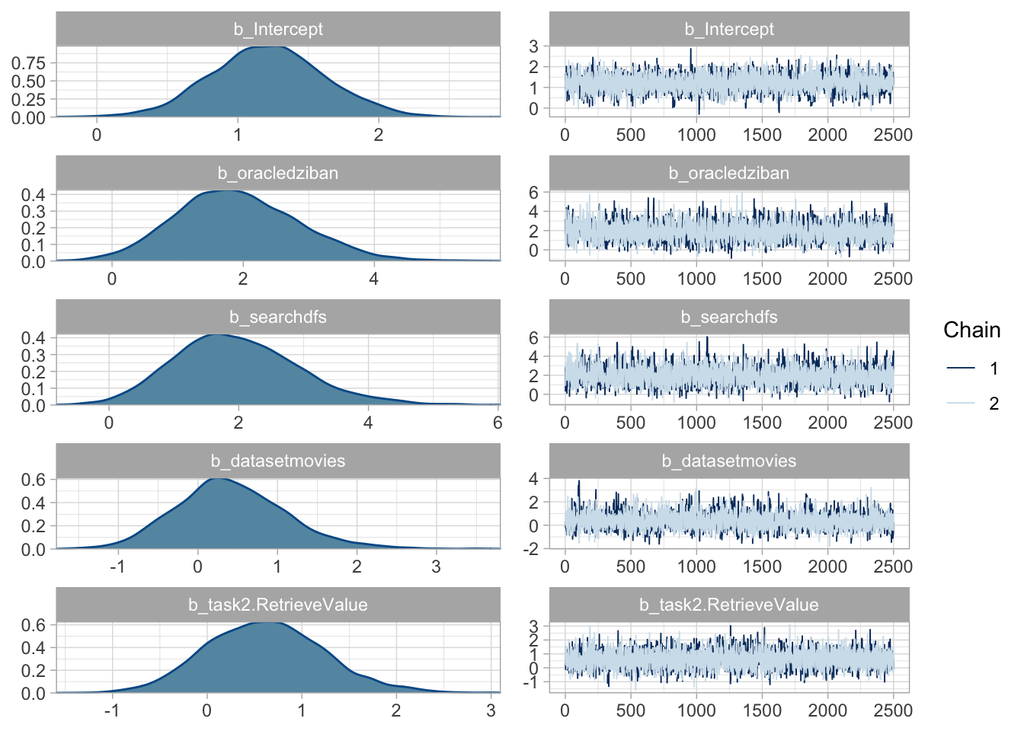

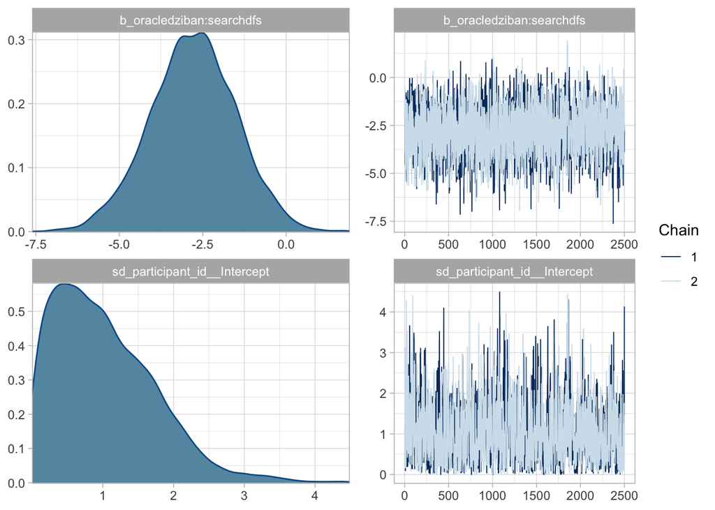

```r
plot(model)
```

In our pairs plots, we want to make sure we don’t have highly correlated parameters (highly correlated parameters means that our model has difficulty differentiating the effect of such parameters).

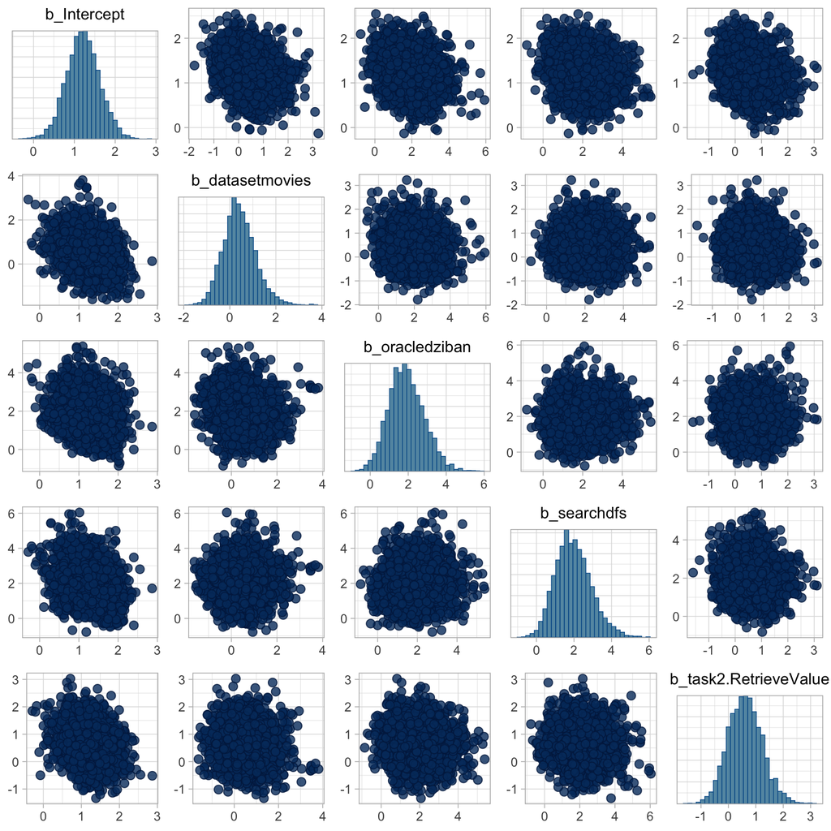

```r
pairs(
  model,
  pars = c("b_Intercept",
            "b_datasetmovies",
           "b_oracledziban",
           "b_searchdfs",
           "b_task2.RetrieveValue"),
  fixed = TRUE
)
```

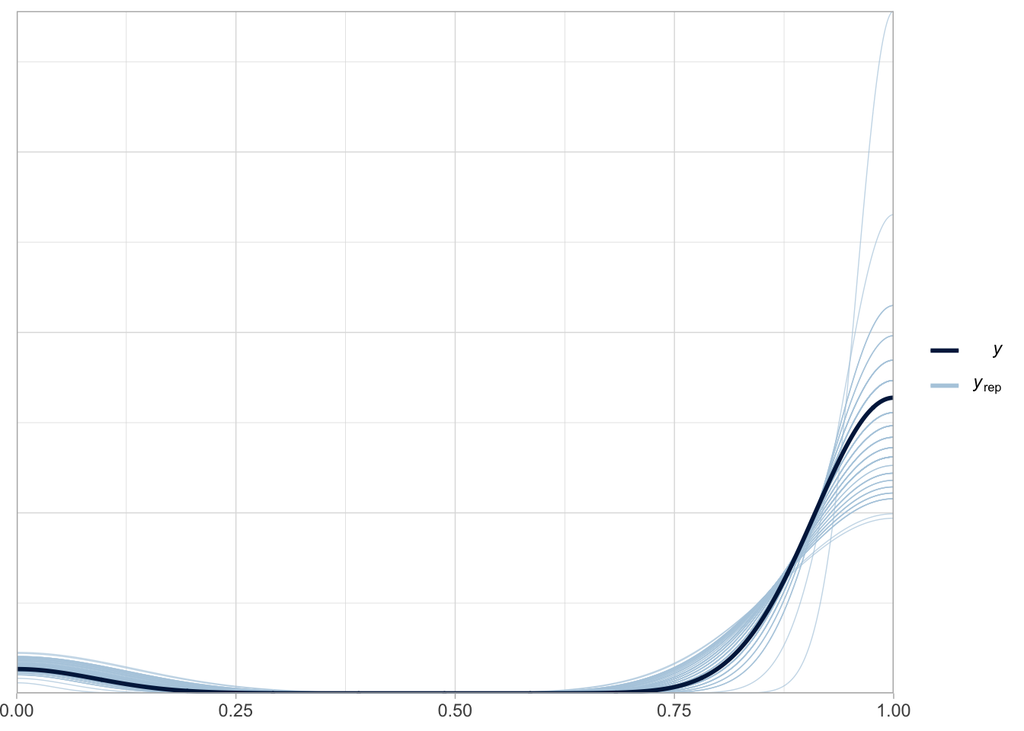

```r
pp_check(model, type = "dens_overlay", nsamples = 100)
```

A confusion matrix can be used to check our correct classification rate (a useful measure to see how well our model fits our data).

```r
pred <- predict(model, type = "response")
pred <- if_else(pred[,1] > 0.5, 1, 0)
confusion_matrix <- table(pred, pull(accuracy_data, accuracy))
confusion_matrix
```

```
##
## pred   0   1
##    1  10 122
```

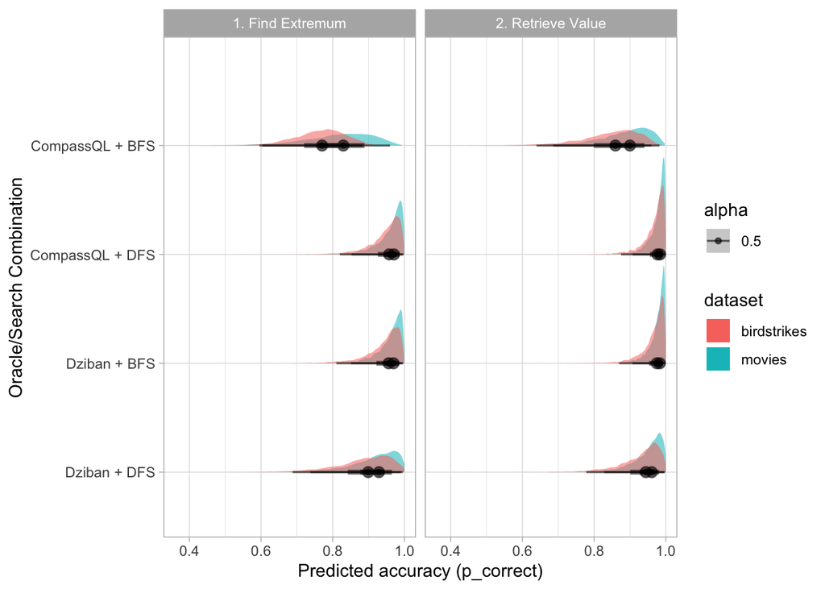

```r
draw_data <- accuracy_data %>%
  add_fitted_draws(model, seed = seed, re_formula = NA, scale = "response") %>%
  group_by(search, oracle, dataset, task, .draw)

plot_data <- draw_data
plot_data$oracle<- gsub('compassql', 'CompassQL', plot_data$oracle)
plot_data$oracle<- gsub('dziban', 'Dziban', plot_data$oracle)
plot_data$search<- gsub('bfs', 'BFS', plot_data$search)
plot_data$search<- gsub('dfs', 'DFS', plot_data$search)

plot_data$condition <- paste(plot_data$oracle, plot_data$search, sep=" + ")

draw_plot <- posterior_draws_plot(plot_data, "dataset", TRUE, "Predicted accuracy (p_correct)", "Oracle/Search Combination")

draw_plot
```

Since the credible intervals on our plot overlap, we can use mean_qi to get the numeric boundaries for the different intervals.

```r
fit_info <-  draw_data %>% group_by(search, oracle, dataset, task) %>% mean_qi(.value, .width = c(.95, .5))
fit_info
```

```
## # A tibble: 32 x 10
## # Groups:   search, oracle, dataset [8]
##    search oracle  dataset  task     .value .lower .upper .width .point .interval
##    <fct>  <fct>   <fct>    <chr>     <dbl>  <dbl>  <dbl>  <dbl> <chr>  <chr>
##  1 bfs    compas… birdstr… 1. Find…  0.763  0.604  0.883   0.95 mean   qi
##  2 bfs    compas… birdstr… 2. Retr…  0.844  0.639  0.960   0.95 mean   qi
##  3 bfs    compas… movies   1. Find…  0.816  0.595  0.960   0.95 mean   qi
##  4 bfs    compas… movies   2. Retr…  0.883  0.686  0.982   0.95 mean   qi
##  5 bfs    dziban  birdstr… 1. Find…  0.942  0.810  0.994   0.95 mean   qi
##  6 bfs    dziban  birdstr… 2. Retr…  0.964  0.870  0.997   0.95 mean   qi
##  7 bfs    dziban  movies   1. Find…  0.958  0.851  0.997   0.95 mean   qi
##  8 bfs    dziban  movies   2. Retr…  0.975  0.907  0.998   0.95 mean   qi
##  9 dfs    compas… birdstr… 1. Find…  0.944  0.820  0.995   0.95 mean   qi
## 10 dfs    compas… birdstr… 2. Retr…  0.967  0.875  0.998   0.95 mean   qi
## # … with 22 more rows
```

### Differences Between Conditions

Next, we want to see if there is any significant difference in accuracy between the two search algorithms (bfs and dfs), the two oracles (dzbian and compassql), and the participant groups (student and professional).

```r
predictive_data  <- accuracy_data %>%
    add_fitted_draws(model, seed = seed, re_formula = NA, scale = "response")
```

Differences in search algorithms:

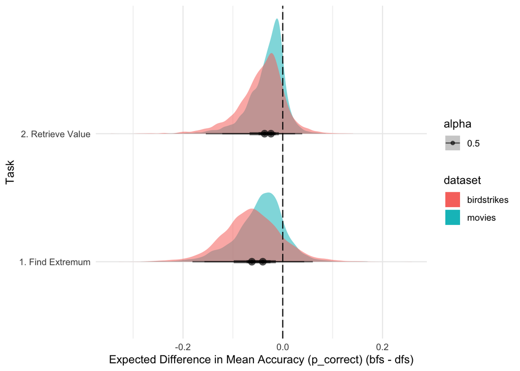

```r
search_differences <- expected_diff_in_mean_plot(predictive_data, "search", "Expected Difference in Mean Accuracy (p_correct)",  "Task", "dataset")
search_differences$plot
```

We can double-check the boundaries of the credible intervals to be sure whether or not the interval contains zero.

```r
search_differences$intervals
```

```
## # A tibble: 8 x 9
## # Groups:   search, dataset [2]
##   search   dataset   task          diff  .lower   .upper .width .point .interval
##   <chr>    <fct>     <chr>        <dbl>   <dbl>    <dbl>  <dbl> <chr>  <chr>
## 1 bfs - d… birdstri… 1. Find E… -0.0613 -0.181   0.0603    0.95 mean   qi
## 2 bfs - d… birdstri… 2. Retrie… -0.0430 -0.154   0.0390    0.95 mean   qi
## 3 bfs - d… movies    1. Find E… -0.0455 -0.157   0.0430    0.95 mean   qi
## 4 bfs - d… movies    2. Retrie… -0.0309 -0.121   0.0247    0.95 mean   qi
## 5 bfs - d… birdstri… 1. Find E… -0.0613 -0.0983 -0.0246    0.5  mean   qi
## 6 bfs - d… birdstri… 2. Retrie… -0.0430 -0.0665 -0.0140    0.5  mean   qi
## 7 bfs - d… movies    1. Find E… -0.0455 -0.0725 -0.0139    0.5  mean   qi
## 8 bfs - d… movies    2. Retrie… -0.0309 -0.0484 -0.00783   0.5  mean   qi
```

Differences in oracle:

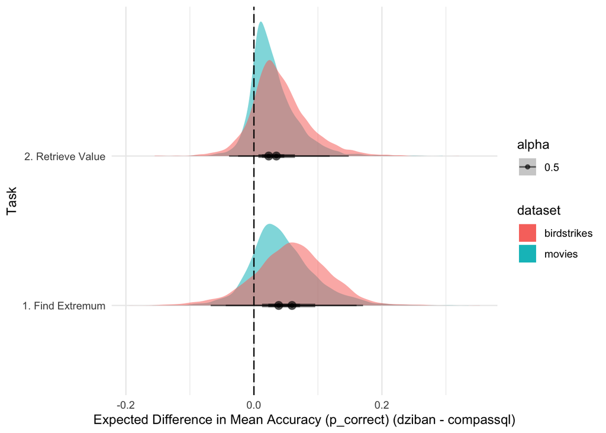

```r
oracle_differences <- expected_diff_in_mean_plot(predictive_data, "oracle", "Expected Difference in Mean Accuracy (p_correct)",  "Task", "dataset")
oracle_differences$plot
```

We can double-check the boundaries of the credible intervals to be sure whether or not the interval contains zero.

```r
oracle_differences$intervals
```

```
## # A tibble: 8 x 9
## # Groups:   oracle, dataset [2]
##   oracle      dataset   task        diff   .lower .upper .width .point .interval
##   <chr>       <fct>     <chr>      <dbl>    <dbl>  <dbl>  <dbl> <chr>  <chr>
## 1 dziban - c… birdstri… 1. Find … 0.0586 -0.0675  0.171    0.95 mean   qi
## 2 dziban - c… birdstri… 2. Retri… 0.0406 -0.0389  0.148    0.95 mean   qi
## 3 dziban - c… movies    1. Find … 0.0450 -0.0440  0.160    0.95 mean   qi
## 4 dziban - c… movies    2. Retri… 0.0302 -0.0247  0.118    0.95 mean   qi
## 5 dziban - c… birdstri… 1. Find … 0.0586  0.0225  0.0958   0.5  mean   qi
## 6 dziban - c… birdstri… 2. Retri… 0.0406  0.0126  0.0641   0.5  mean   qi
## 7 dziban - c… movies    1. Find … 0.0450  0.0127  0.0720   0.5  mean   qi
## 8 dziban - c… movies    2. Retri… 0.0302  0.00701 0.0475   0.5  mean   qi
```

Differences in participant group (student vs professional):

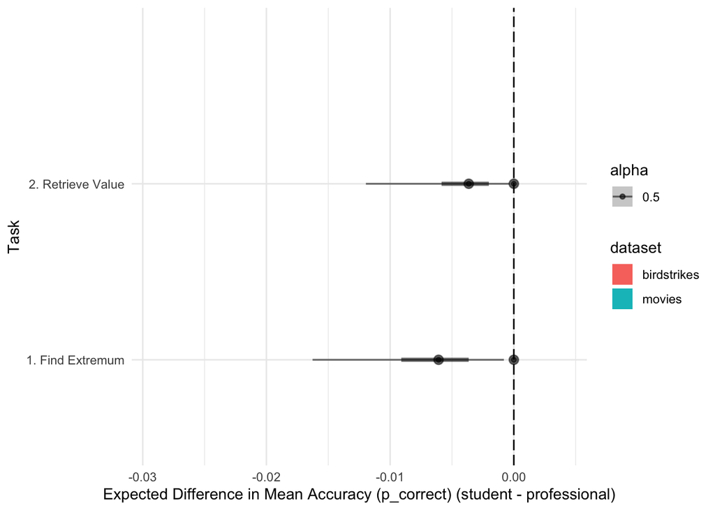

```r
participant_group_differences <- expected_diff_in_mean_plot(predictive_data, "participant_group", "Expected Difference in Mean Accuracy (p_correct)", "Task", "dataset")
participant_group_differences$plot
```

We can double-check the boundaries of the credible intervals to be sure whether or not the interval contains zero.

```r
participant_group_differences$intervals
```

```
## # A tibble: 8 x 9
## # Groups:   participant_group, dataset [2]
##   participant_gro… dataset task       diff    .lower    .upper .width .point
##   <chr>            <fct>   <chr>     <dbl>     <dbl>     <dbl>  <dbl> <chr>
## 1 student - profe… birdst… 1. F…  4.44e-19 -1.11e-16  1.11e-16   0.95 mean
## 2 student - profe… birdst… 2. R… -3.77e-19 -1.11e-16  1.11e-16   0.95 mean
## 3 student - profe… movies  1. F… -6.72e- 3 -1.63e- 2 -8.04e- 4   0.95 mean
## 4 student - profe… movies  2. R… -4.31e- 3 -1.20e- 2 -3.67e- 4   0.95 mean
## 5 student - profe… birdst… 1. F…  4.44e-19 -1.11e-16  1.11e-16   0.5  mean
## 6 student - profe… birdst… 2. R… -3.77e-19 -1.11e-16  1.11e-16   0.5  mean
## 7 student - profe… movies  1. F… -6.72e- 3 -9.10e- 3 -3.65e- 3   0.5  mean
## 8 student - profe… movies  2. R… -4.31e- 3 -5.84e- 3 -2.02e- 3   0.5  mean
## # … with 1 more variable: .interval <chr>
```